# Map ROMS data to Ecopath GOA

Alberto Rovellini

5/11/2021

Based on code from Owen Liu and Alberto Rovellini.

# Purpose

This document illustrates the workflow to pull static variables from ROMS NetCDF output and map it to the model area of Ecopath models for the Gulf of Alaska.

```r
select <- dplyr::select
```

# Read data

## Read Ecopath mask

Load the Ecopath spatial masks.

```r
mask <- st_read("EGOA.shp")
#mask <- mask %>% st_combine()
```

Have a look.

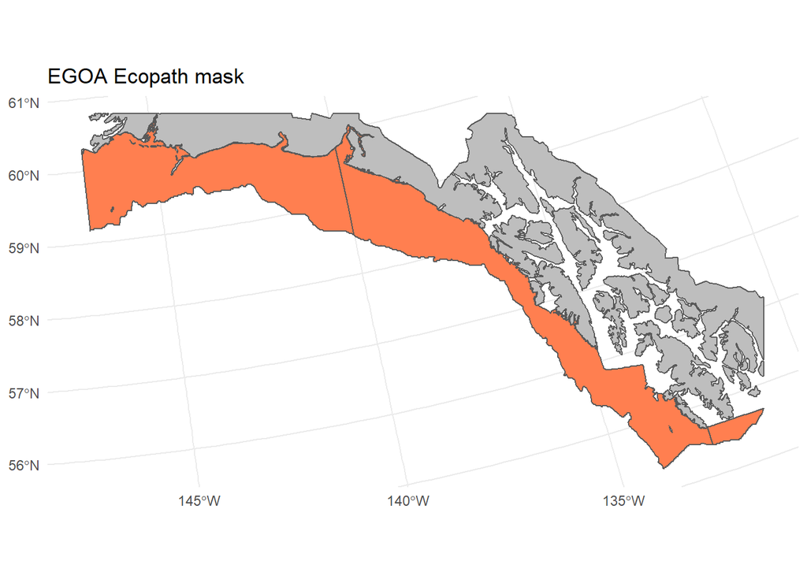

```r
coast <- map("worldHires", regions = "USA", plot = FALSE, fill = TRUE)
coast <- coast %>% st_as_sf() %>% st_transform(crs = st_crs(mask)) %>% st_crop(st_bbox(mask))
ggplot()+
  geom_sf(data = mask, fill = "coral")+
  geom_sf(data = coast, fill = "grey")+
  theme_minimal()+
  labs(title = "EGOA Ecopath mask")
```

## Import ROMS data

For GOA, we have grid information stored in a grid file, and the variables stored in the netCDF files.

```r
roms_grid <- tidync("data/ROMS/CGOA_grid_5.nc")
roms_vars <- tidync("data/ROMS/cgoa_avg_0793.nc")
```

Some information about this NetCDF.

```r
print(roms_vars)
```

```
##
## Data Source (1): cgoa_avg_0793.nc ...
##
## Grids (14) <dimension family> : <associated variables>
##
## [1]   D0,D4,D8,D12 : temp, salt, NO3, NH4, PhS, PhL, MZS, MZL, Cop, NCa, Eup, Det, Iron, prod_PhS, prod_PhL, prod_MZS, prod_MZL, prod_Cop, prod_NCa, prod_Eup, frat_PhS, frat_PhL, CChl_PhS, CChl_PhL
## [2]   D0,D4,D9,D12 : omega, w, AKv, AKt, AKs
## [3]   D1,D5,D8,D12 : u    **ACTIVE GRID** ( 97373640  values per variable)
## [4]   D2,D6,D8,D12 : v
## [5]   D0,D4,D12    : zeta, Hsbl, Hbbl, shflux, ssflux, latent, sensible, lwrad, swrad
## [6]   D1,D5,D12    : ubar, sustr, bustr
## [7]   D2,D6,D12    : vbar, svstr, bvstr
## [8]   D10,D11      : Tobc_in, Tobc_out
## [9]   D10          : tnu2, Akt_bak, Tnudg
## [10]   D11          : FSobc_in, FSobc_out, M2obc_in, M2obc_out, M3obc_in, M3obc_out
## [11]   D12          : ocean_time
## [12]   D8           : s_rho, Cs_r
## [13]   D9           : s_w, Cs_w
## [14]   S            : ntimes, ndtfast, dt, dtfast, dstart, nHIS, ndefHIS, nRST, ntsAVG, nAVG, ndefAVG, nSTA, Falpha, Fbeta, Fgamma, visc2, Akv_bak, rdrg, rdrg2, Zob, Zos, Znudg, M2nudg, M3nudg, rho0, gamma2, spherical, xl, el, Vtransform, Vstretching, theta_s, theta_b, Tcline, hc
##
## Dimensions 13 (4 active):
##
##   dim   name       length      min      max start count     dmin     dmax unlim
##   <chr> <chr>       <dbl>    <dbl>    <dbl> <int> <int>    <dbl>    <dbl> <lgl>
## 1 D1    xi_u          481  1   e+0  4.81e+2     1   481  1   e+0  4.81e+2 FALSE
## 2 D5    eta_u         482  1   e+0  4.82e+2     1   482  1   e+0  4.82e+2 FALSE
## 3 D8    s_rho          42 -9.88e-1 -1.19e-2     1    42 -9.88e-1 -1.19e-2 FALSE
## 4 D12   ocean_time     10  3.71e+9  3.71e+9     1    10  3.71e+9  3.71e+9 TRUE
## # ... with 1 more variable: coord_dim <lgl>
##
## Inactive dimensions:
##
##   dim   name     length   min   max unlim coord_dim
##   <chr> <chr>     <dbl> <dbl> <dbl> <lgl> <lgl>
## 1 D0    xi_rho      482     1   482 FALSE FALSE
## 2 D2    xi_v        482     1   482 FALSE FALSE
## 3 D3    xi_psi      481    NA    NA FALSE FALSE
## 4 D4    eta_rho     482     1   482 FALSE FALSE
## 5 D6    eta_v       481     1   481 FALSE FALSE
## 6 D7    eta_psi     481    NA    NA FALSE FALSE
## 7 D9    s_w          43    -1     0 FALSE TRUE
## 8 D10   tracer       13     1    13 FALSE FALSE
## 9 D11   boundary      4     1     4 FALSE FALSE
```

Get variables. We do not need water velocity, so we can ignore $u$ and $v$ points. Also we should not need depth, so actually all that matters is 2D indexing for $\rho$ points.

```r
#grid info
grid_variables <- hyper_grids(roms_grid) %>% # all available grids in the ROMS ncdf
  pluck("grid") %>% # for each grid, pull out all the variables asssociated with that grid and make a reference table
  purrr::map_df(function(x){
    roms_grid %>% activate(x) %>% hyper_vars() %>%
      mutate(grd=x)
  })
#variables
roms_variables <- hyper_grids(roms_vars) %>% # all available grids in the ROMS ncdf
  pluck("grid") %>% # for each grid, pull out all the variables asssociated with that grid and make a reference table
  purrr::map_df(function(x){
    roms_vars %>% activate(x) %>% hyper_vars() %>%
      mutate(grd=x)
  })
```

Get some information about time.

```r
ncmeta::nc_atts("data/ROMS/three_steps.nc", "ocean_time") %>% tidyr::unnest(cols = c(value))
```

```
## # A tibble: 5 x 4
##      id name          variable   value
##   <int> <chr>         <chr>      <chr>
## 1     0 standard_name ocean_time time
## 2     1 long_name     ocean_time averaged time since initialization
## 3     2 units         ocean_time seconds since 1900-01-01 00:00:00
## 4     3 calendar      ocean_time gregorian
## 5     4 axis          ocean_time T
```

```r
time_grid <- roms_variables %>% filter(name=="ocean_time") %>% pluck('grd')
# pull the lon/lats
time_steps <- roms_vars %>% activate(time_grid) %>% hyper_tibble() %>% mutate(ts=row_number()) # add index
```

```r
# find appropriate ROMS ncdf grid for the rho points
latlon_rhogrd <- grid_variables %>% filter(name=="lat_rho") %>% pluck('grd')
# pull the lon/lats
roms_rho <- roms_grid %>% activate(latlon_rhogrd) %>% hyper_tibble() %>% select(lon_rho,lat_rho,xi_rho,eta_rho) %>%
  mutate(rhoidx=row_number()) # add index
```

Add coordinates in the CRS used by the Ecopath mask.

```r
append_xy_coords <- function(lonlatdat, xyproj=crs(mask)@projargs, lon_col="lon_rho", lat_col="lat_rho"){
  lonlatdat %>%
    st_as_sf(coords=c(lon_col, lat_col), crs=4326, remove=F) %>%  # convert to spatial object
    st_transform(xyproj) %>%  # convert to Atlantis coords
    mutate(x = st_coordinates(.)[,1],
           y = st_coordinates(.)[,2]) # grab x and y coordinates and add them as attributes
}

rhoxy<- append_xy_coords(roms_rho,lon_col="lon_rho",lat_col="lat_rho") %>% mutate(rhoidx=row_number())
```

# Match ROMS and Ecopath

Join $\rho$ points to the Ecopath mask. Do a spatial join.

```r
rho_join <- mask %>% st_join(rhoxy) %>% na.omit()
```

Test that we are pulling the right points.

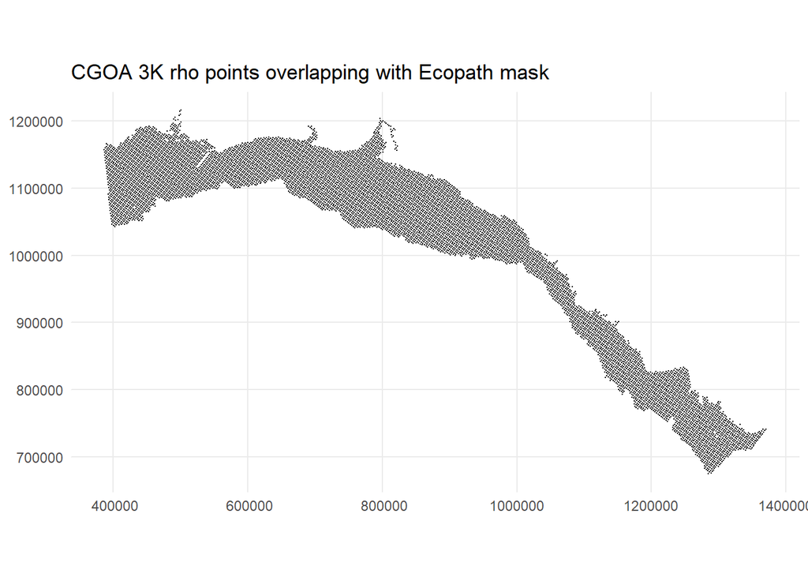

```r
rho_join %>%
  st_set_geometry(NULL) %>%
  st_as_sf(coords = c("x", "y")) %>%
  ggplot()+
  geom_sf(size = 0.1)+
  theme_minimal()+
  labs(title = "CGOA 3K rho points overlapping with Ecopath mask")
```

# Pull variables from ROMS

Need to pull time in this function, or else it will be a very large array. In addition, we may subset to the xi and eta identified from the join, instead of pulling out the entire array. Might be good for memory economy.

```r
rho_join <- rho_join %>% st_set_geometry(NULL)
# function to pull ROMS data
# for now, this should work with things like salt, temp, u, v, w
# returns an array with all of the data from the one time-slice of ROMS
pull_var <- function(variable,time_step){
  grd <- roms_variables %>% filter(name==variable) %>% pluck('grd')
  dat <- roms_vars %>% activate(grd) %>%
    hyper_filter(ocean_time = index == time_step) %>%
    hyper_array()
  return(dat[[variable]])
}
# index into the variable array using xi, eta, and s indices
join_var <- function(a,xi,eta) a[xi,eta,]
```

Pull ROMS variables, once per time step. We could also subset spatially here, to make things faster, but it will take some thinking.

```r
roms_to_ecopath <- function(ts) {
  # pull static variables for this time step (add variables if we want more, e.g. NPZ etc.)
  salt <- pull_var('salt',ts)
  temperature <- pull_var('temp',ts)

  # join rho points
  roms_salt_temp <- rho_join %>%
    mutate(salt_vec=pmap(list(xi_rho,eta_rho),join_var,a=salt),
           temp_vec=pmap(list(xi_rho,eta_rho),join_var,a=temperature))

  # Integrate over depth (average or sum, depending on the variable)
  roms_salt_temp_int <- roms_salt_temp %>% mutate(salt = unlist(pmap(list(salt_vec),mean,na.tm=TRUE)),
                                                  temp = unlist(pmap(list(temp_vec),mean,na.rm=TRUE)))

  # average over the area, or use other appropriate statistic (e.g. sum for NPZ variables, etc.)
  salt_ts <- mean(roms_salt_temp_int$salt,na.rm=TRUE)
  temp_ts <- mean(roms_salt_temp_int$temp,na.rm=TRUE)

  vars_ts <- data.frame(salt_ts,temp_ts)
  return(vars_ts)
}

epoch <- "1900-01-01" #important, check that this is your correct start - keeping this generic as it changes a lot ROMS by ROMS

ecopath_vars <- rbindlist(purrr::map(time_steps$ts,roms_to_ecopath))
ecopath_vars <- ecopath_vars %>% mutate(time_step = 1:nrow(.),
                                        date = as.POSIXct(time_steps$ocean_time, origin = epoch, tz = "GMT")) %>% select(time_step, date, temp_ts, salt_ts)
```

View.

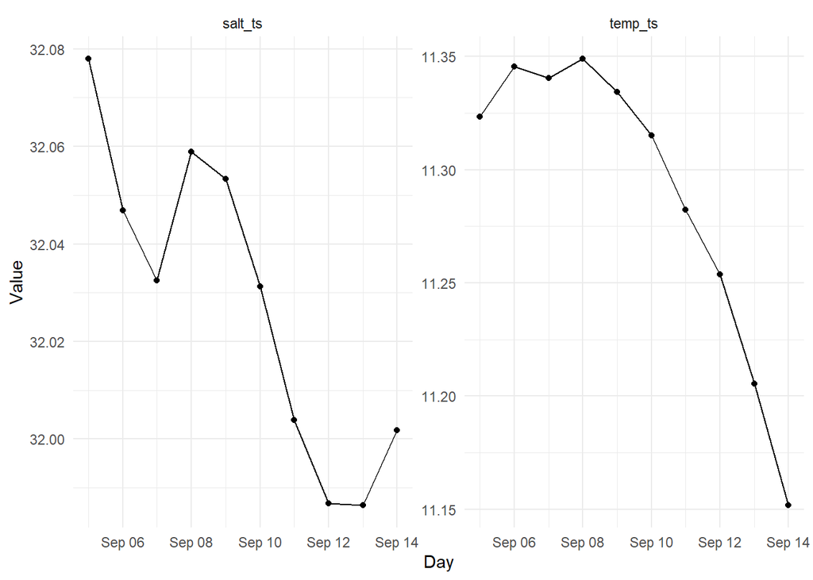

```r
ecopath_vars %>%
  pivot_longer(cols = ends_with("_ts"), names_to = "variable", values_to = "value") %>%
  arrange(variable) %>%
  ggplot(aes(x = as.Date(date, format='%m/%d/%Y'), y = value))+
  geom_point()+
  geom_line()+
  theme_minimal()+
  facet_wrap(~variable, scales = "free")+
  xlab("Day")+
  ylab("Value")
```